# final project

2023-03-21

```r
options(scipen=999)
knitr::opts_chunk$set(echo = TRUE)
library(tidyverse)
library(caret)
Heart_sample=as.tibble(read.csv("heart.csv"))
head(Heart_sample)
```

```
## # A tibble: 6 × 12
##     Age Sex   ChestPainType RestingBP Cholesterol FastingBS RestingECG MaxHR
##   <int> <chr> <chr>             <int>       <int>     <int> <chr>      <int>
## 1    40 M     ATA                 140         289         0 Normal       172
## 2    49 F     NAP                 160         180         0 Normal       156
## 3    37 M     ATA                 130         283         0 ST            98
## 4    48 F     ASY                 138         214         0 Normal       108
## 5    54 M     NAP                 150         195         0 Normal       122
## 6    39 M     NAP                 120         339         0 Normal       170
## # ℹ 4 more variables: ExerciseAngina <chr>, Oldpeak <dbl>, ST_Slope <chr>,
## #   HeartDisease <int>
```

Q10

```r
Heart_sample1 = Heart_sample[c(12,1,4,5,6,8,10)]
head(Heart_sample1)
```

```
## # A tibble: 6 × 7
##   HeartDisease   Age RestingBP Cholesterol FastingBS MaxHR Oldpeak
##          <int> <int>     <int>       <int>     <int> <int>   <dbl>
## 1            0    40       140         289         0   172     0
## 2            1    49       160         180         0   156     1
## 3            0    37       130         283         0    98     0
## 4            1    48       138         214         0   108     1.5
## 5            0    54       150         195         0   122     0
## 6            0    39       120         339         0   170     0
```

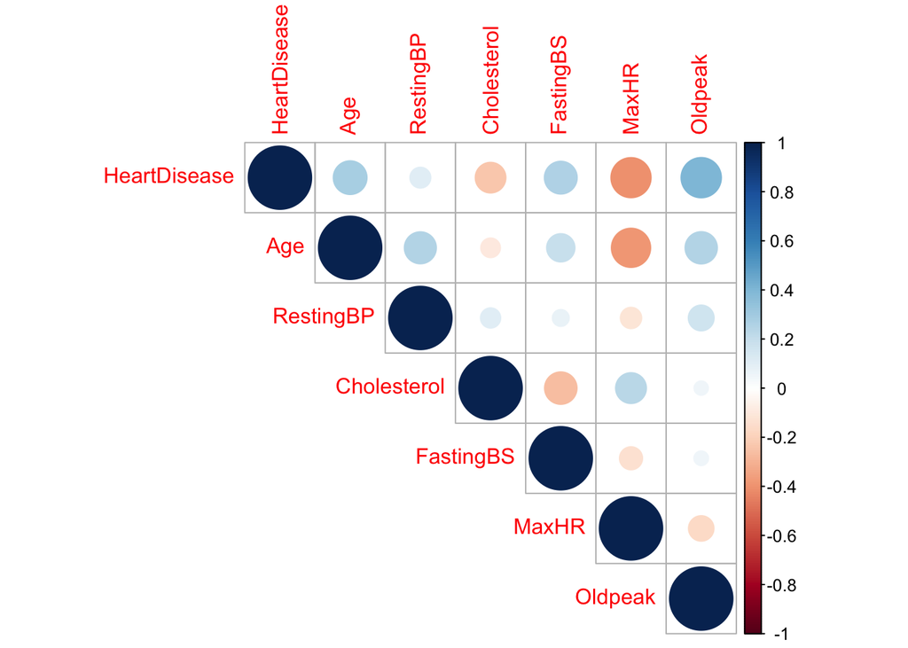

```r
library(corrplot)
corrplot(cor(Heart_sample1), type = "upper")
```

While some predictors are boolean or categorical, I created a new dataset that only include the numeric predictors, including age, cholesterol, fastingbs, maxhr, and old peak. Based on the ouput, MaxHr tends to have the strongest negative correlation with heart disease. Meanwhile, oldpeak seems to have a strongest positive correlation with heart disease. Comparatively, the predictors, age, cholesterol, and fasting bs also demonstrate a moderate correlation with heart disease.

To further elaborate the output and obtain a best fit model, I will utilize Backward elimination. .

```r
Full = lm(HeartDisease~., data = Heart_sample1)
MSE=(summary(Full)$sigma)^2
step(Full,scale=MSE)
```

```
## Start:  AIC=7
## HeartDisease ~ Age + RestingBP + Cholesterol + FastingBS + MaxHR +
##     Oldpeak
##
##               Df Sum of Sq    RSS       Cp
## - RestingBP    1    0.0314 150.01   5.1909
## - Age          1    0.2515 150.23   6.5277
## <none>                     149.98   7.0000
## - Cholesterol  1    3.8010 153.78  28.0885
## - FastingBS    1    5.7748 155.75  40.0777
## - MaxHR        1   13.7245 163.70  88.3661
## - Oldpeak      1   24.7916 174.77 155.5909
##
## Step:  AIC=5.19
## HeartDisease ~ Age + Cholesterol + FastingBS + MaxHR + Oldpeak
##
##               Df Sum of Sq    RSS       Cp
## - Age          1    0.3003 150.31   5.0148
## <none>                     150.01   5.1909
## - Cholesterol  1    3.7779 153.79  26.1388
## - FastingBS    1    5.8369 155.84  38.6457
## - MaxHR        1   13.7940 163.80  86.9790
## - Oldpeak      1   25.1696 175.18 156.0779
##
## Step:  AIC=5.01
## HeartDisease ~ Cholesterol + FastingBS + MaxHR + Oldpeak
##
##               Df Sum of Sq    RSS       Cp
## <none>                     150.31   5.0148
## - Cholesterol  1    3.7517 154.06  25.8039
## - FastingBS    1    6.4160 156.72  41.9870
## - MaxHR        1   17.1448 167.45 107.1571
## - Oldpeak      1   27.5826 177.89 170.5587
```

```
##
## Call:
## lm(formula = HeartDisease ~ Cholesterol + FastingBS + MaxHR +
##     Oldpeak, data = Heart_sample1)
##
## Coefficients:
## (Intercept)  Cholesterol    FastingBS        MaxHR      Oldpeak
##   1.2520625   -0.0006229    0.2057158   -0.0056272    0.1657082
```

Then, I will use Forward selection.

```r
none = lm(HeartDisease~1, data=Heart_sample1)
step(none, scope=list(upper=Full), scale=MSE, direction='forward')
```

```
## Start:  AIC=462.16
## HeartDisease ~ 1
##
##               Df Sum of Sq    RSS     Cp
## + Oldpeak      1    37.022 189.86 239.27
## + MaxHR        1    36.378 190.51 243.19
## + Age          1    18.048 208.84 354.53
## + FastingBS    1    16.210 210.68 365.69
## + Cholesterol  1    12.290 214.59 389.50
## + RestingBP    1     2.626 224.26 448.20
## <none>                     226.88 462.16
##
## Step:  AIC=239.27
## HeartDisease ~ Oldpeak
##
##               Df Sum of Sq    RSS      Cp
## + MaxHR        1   26.2166 163.65  82.027
## + Cholesterol  1   14.5590 175.30 152.839
## + FastingBS    1   13.7688 176.09 157.639
## + Age          1    7.6669 182.20 194.703
## + RestingBP    1    0.3924 189.47 238.891
## <none>                     189.86 239.274
##
## Step:  AIC=82.03
## HeartDisease ~ Oldpeak + MaxHR
##
##               Df Sum of Sq    RSS     Cp
## + FastingBS    1    9.5853 154.06 25.804
## + Cholesterol  1    6.9211 156.72 41.987
## + Age          1    1.0136 162.63 77.871
## <none>                     163.65 82.027
## + RestingBP    1    0.0312 163.62 83.838
##
## Step:  AIC=25.8
## HeartDisease ~ Oldpeak + MaxHR + FastingBS
##
##               Df Sum of Sq    RSS      Cp
## + Cholesterol  1    3.7517 150.31  5.0148
## <none>                     154.06 25.8039
## + Age          1    0.2741 153.79 26.1388
## + RestingBP    1    0.0002 154.06 27.8024
##
## Step:  AIC=5.01
## HeartDisease ~ Oldpeak + MaxHR + FastingBS + Cholesterol
##
##             Df Sum of Sq    RSS     Cp
## <none>                   150.31 5.0148
## + Age        1   0.30028 150.01 5.1909
## + RestingBP  1   0.08020 150.23 6.5277
```

```
##
## Call:
## lm(formula = HeartDisease ~ Oldpeak + MaxHR + FastingBS + Cholesterol,
##     data = Heart_sample1)
##
## Coefficients:
## (Intercept)      Oldpeak        MaxHR    FastingBS  Cholesterol
##   1.2520625    0.1657082   -0.0056272    0.2057158   -0.0006229
```

Lastly, I will use stepwise regression.

```r
step(none,scope=list(upper=Full),scale=MSE)
```

```
## Start:  AIC=462.16
## HeartDisease ~ 1
##
##               Df Sum of Sq    RSS     Cp
## + Oldpeak      1    37.022 189.86 239.27
## + MaxHR        1    36.378 190.51 243.19
## + Age          1    18.048 208.84 354.53
## + FastingBS    1    16.210 210.68 365.69
## + Cholesterol  1    12.290 214.59 389.50
## + RestingBP    1     2.626 224.26 448.20
## <none>                     226.88 462.16
##
## Step:  AIC=239.27
## HeartDisease ~ Oldpeak
##
##               Df Sum of Sq    RSS      Cp
## + MaxHR        1    26.217 163.65  82.027
## + Cholesterol  1    14.559 175.30 152.839
## + FastingBS    1    13.769 176.09 157.639
## + Age          1     7.667 182.20 194.703
## + RestingBP    1     0.392 189.47 238.891
## <none>                     189.86 239.274
## - Oldpeak      1    37.022 226.88 462.156
##
## Step:  AIC=82.03
## HeartDisease ~ Oldpeak + MaxHR
##
##               Df Sum of Sq    RSS      Cp
## + FastingBS    1    9.5853 154.06  25.804
## + Cholesterol  1    6.9211 156.72  41.987
## + Age          1    1.0136 162.63  77.871
## <none>                     163.65  82.027
## + RestingBP    1    0.0312 163.62  83.838
## - MaxHR        1   26.2166 189.86 239.274
## - Oldpeak      1   26.8608 190.51 243.187
##
## Step:  AIC=25.8
## HeartDisease ~ Oldpeak + MaxHR + FastingBS
##
##               Df Sum of Sq    RSS       Cp
## + Cholesterol  1    3.7517 150.31   5.0148
## <none>                     154.06  25.8039
## + Age          1    0.2741 153.79  26.1388
## + RestingBP    1    0.0002 154.06  27.8024
## - FastingBS    1    9.5853 163.65  82.0274
## - MaxHR        1   22.0331 176.09 157.6386
## - Oldpeak      1   25.8077 179.87 180.5665
##
## Step:  AIC=5.01
## HeartDisease ~ Oldpeak + MaxHR + FastingBS + Cholesterol
##
##               Df Sum of Sq    RSS       Cp
## <none>                     150.31   5.0148
## + Age          1    0.3003 150.01   5.1909
## + RestingBP    1    0.0802 150.23   6.5277
## - Cholesterol  1    3.7517 154.06  25.8039
## - FastingBS    1    6.4160 156.72  41.9870
## - MaxHR        1   17.1448 167.45 107.1571
## - Oldpeak      1   27.5826 177.89 170.5587
```

```
##
## Call:
## lm(formula = HeartDisease ~ Oldpeak + MaxHR + FastingBS + Cholesterol,
##     data = Heart_sample1)
##
## Coefficients:
## (Intercept)      Oldpeak        MaxHR    FastingBS  Cholesterol
##   1.2520625    0.1657082   -0.0056272    0.2057158   -0.0006229
```

Based on the above output, the bestfit model only considering numeric variables may be lm(HeartDisease ~ Cholesterol + FastingBS + MaxHR + Oldpeak), and thus, the doctor should pay more attention on a patient’s Cholesterol, FastingBS, MaxHR and Oldpeak in considering the potential of heart disease.

Q2 Is heart disease more common in women than in men?

```r
head(Heart_sample)
```

```
## # A tibble: 6 × 12
##     Age Sex   ChestPainType RestingBP Cholesterol FastingBS RestingECG MaxHR
##   <int> <chr> <chr>             <int>       <int>     <int> <chr>      <int>
## 1    40 M     ATA                 140         289         0 Normal       172
## 2    49 F     NAP                 160         180         0 Normal       156
## 3    37 M     ATA                 130         283         0 ST            98
## 4    48 F     ASY                 138         214         0 Normal       108
## 5    54 M     NAP                 150         195         0 Normal       122
## 6    39 M     NAP                 120         339         0 Normal       170
## # ℹ 4 more variables: ExerciseAngina <chr>, Oldpeak <dbl>, ST_Slope <chr>,
## #   HeartDisease <int>
```

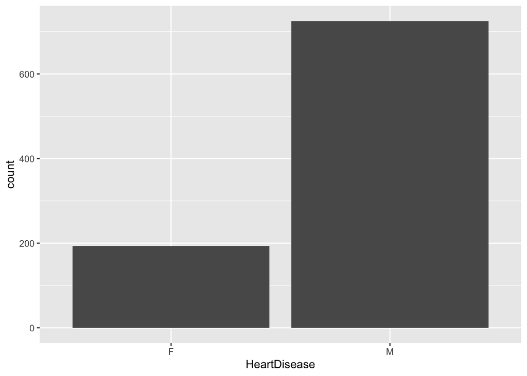

```r
ggplot(Heart_sample,aes(HeartDisease)) + geom_bar(aes(Sex))
```

```r
Heart_female = subset(Heart_sample, Sex == "F")
Heart_male = subset(Heart_sample, Sex == "M")

t.test(Heart_female$HeartDisease, Heart_male$HeartDisease)
```

```
##
##  Welch Two Sample t-test
##
## data:  Heart_female$HeartDisease and Heart_male$HeartDisease
## t = -10.253, df = 326.32, p-value < 0.00000000000000022
## alternative hypothesis: true difference in means is not equal to 0
## 95 percent confidence interval:
##  -0.4441603 -0.3011533
## sample estimates:
## mean of x mean of y
## 0.2590674 0.6317241
```

Based on the output above, while p-value < 0.00000000000000022, which is extremely small, there is strong statistical evidence that male is more likely to get heart disease compared to female.

2nd Meeting

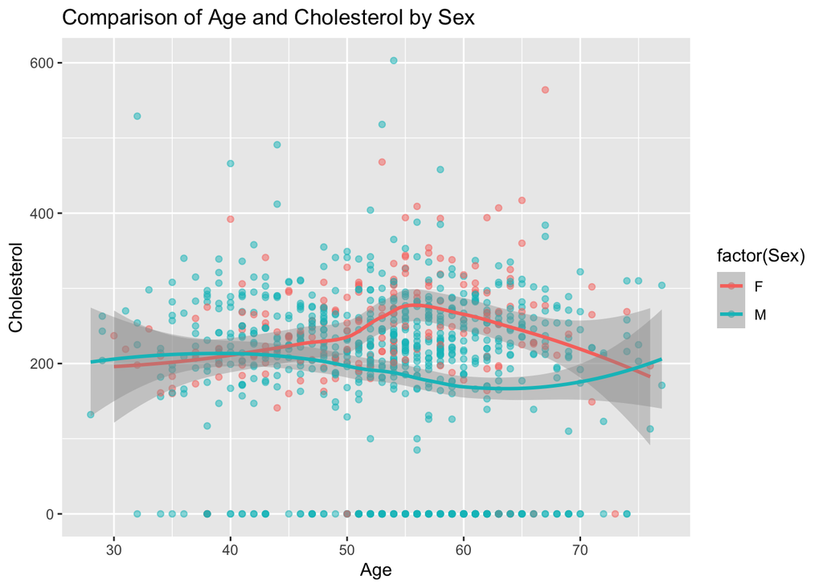

```r
ggplot(data = Heart_sample, aes(x = Age, y = Cholesterol
, color = factor(Sex))) +
  geom_point(alpha = 0.5) +
  geom_smooth()+
  labs(title = "Comparison of Age and Cholesterol by Sex")
```

```r
Heart_sample2 <- table(Heart_sample$Sex, Heart_sample$ChestPainType == "ASY")

chisq.test(Heart_sample2)
```

```
##
##  Pearson's Chi-squared test with Yates' continuity correction
##
## data:  Heart_sample2
## X-squared = 30.139, df = 1, p-value = 0.00000004022
```

[figure not shown]

```r
barplot(
  rbind(Heart_sample2[1, ], Heart_sample2[2, ]),
  beside = TRUE,
  names.arg = c("Female", "Male"),
  col = c("steelblue", "lightblue")
)

legend("top", legend = c("Other Types", "ASY"), fill = c("steelblue", "lightblue"))
```

The result of a chi-squared test is large, such that the p-value is small, it means that the observed values in the contingency table are not close to the expected values. This suggests that there may be a significant association between the variables being tested (in this case, sex and chest pain type).

**Final**：

To investigate the potential relationship between an individual’s sex and the type of chest pain they experience, we use a contingency table and a chi-squared test of independence. Baed on the result of the chi-squared test, it suggests that there is a significant association between the variables ‘Sex’ and ‘ChestPainType’ at a statistically significant level. The chi-squared statistic value of 30.139 indicates that the difference between the observed frequencies and expected frequencies is relatively large, which suggests that the association between the variables is not likely due to chance. The degrees of freedom (df) for this test is 1, which indicates that the contingency table has one degree of freedom since there are only two variables in the table. The p-value of 0.00000004022 suggests that the likelihood of observing such a large difference between the observed and expected frequencies, assuming there is no association between the variables, is very low. Therefore, we can reject the null hypothesis that there is no association between the variables ‘Sex’ and ‘ChestPainType’. Instead, we can conclude that there is a significant association between these variables in the sample. Consequently, it may be useful to consider this information when diagnosing and treating patients with chest pain. Specifically, the healthcare provider may consider asking questions about the type of chest pain experienced by patients, as well as their sex, to help inform their diagnosis and treatment plan. They may also consider incorporating sex-specific risk factors for cardiovascular disease, as well as any potential differences in symptoms and presentation of chest pain, into their assessment.

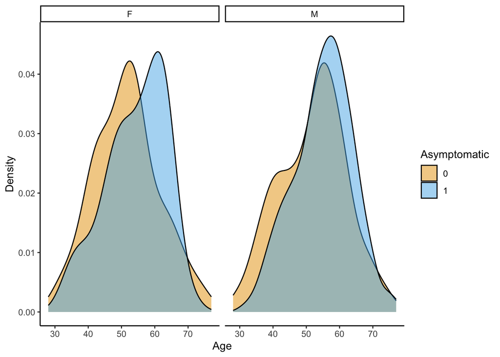

```r
heart_subset <- subset(Heart_sample, select = c(Age, Sex, ChestPainType))

heart_subset$asymptomatic <- ifelse(heart_subset$ChestPainType == "ASY", 1, 0)

ggplot(heart_subset, aes(x = Age, fill = factor(asymptomatic))) +
  geom_density(alpha = 0.5) +
  facet_grid(. ~ Sex) +
  scale_fill_manual(values = c("#E69F00", "#56B4E9")) +
  labs(x = "Age", y = "Density", fill = "Asymptomatic") +
  theme_classic()
```

```r
# Logistic regression model

trainIndex <- createDataPartition(heart_subset$ChestPainType, p = .8, list = FALSE)
train <- heart_subset[ trainIndex,]
test <- heart_subset[-trainIndex,]

log_reg_model <- glm(asymptomatic ~ Age + Sex, data = train, family = "binomial")
summary(log_reg_model)
```

```
##
## Call:
## glm(formula = asymptomatic ~ Age + Sex, family = "binomial",
##     data = train)
##
## Deviance Residuals:
##     Min       1Q   Median       3Q      Max
## -1.7054  -1.1824   0.8541   1.0358   1.7414
##
## Coefficients:
##              Estimate Std. Error z value     Pr(>|z|)
## (Intercept) -2.555031   0.474875  -5.380 0.0000000743 ***
## Age          0.036760   0.008384   4.384 0.0000116318 ***
## SexM         0.949441   0.189823   5.002 0.0000005682 ***
## ---
## Signif. codes:  0 '***' 0.001 '**' 0.01 '*' 0.05 '.' 0.1 ' ' 1
##
## (Dispersion parameter for binomial family taken to be 1)
##
##     Null deviance: 1015.7  on 735  degrees of freedom
## Residual deviance:  966.1  on 733  degrees of freedom
## AIC: 972.1
##
## Number of Fisher Scoring iterations: 4
```

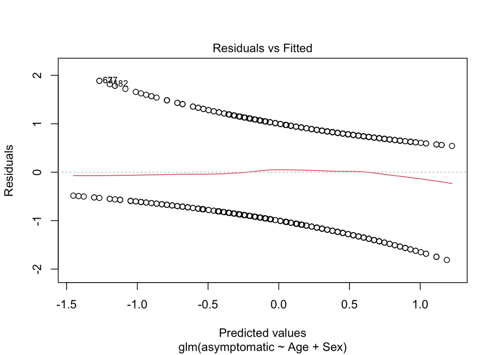

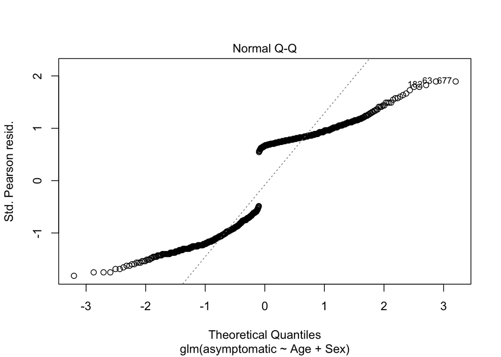

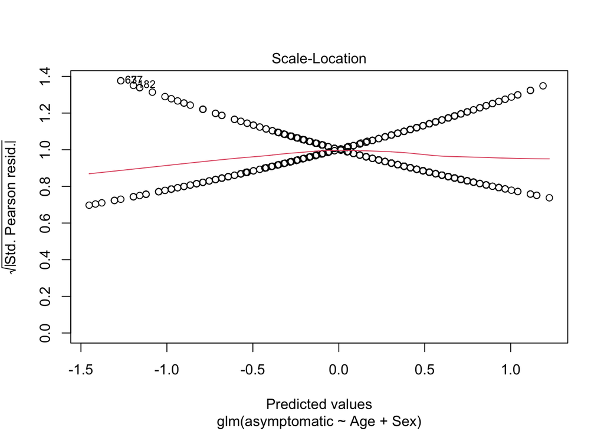

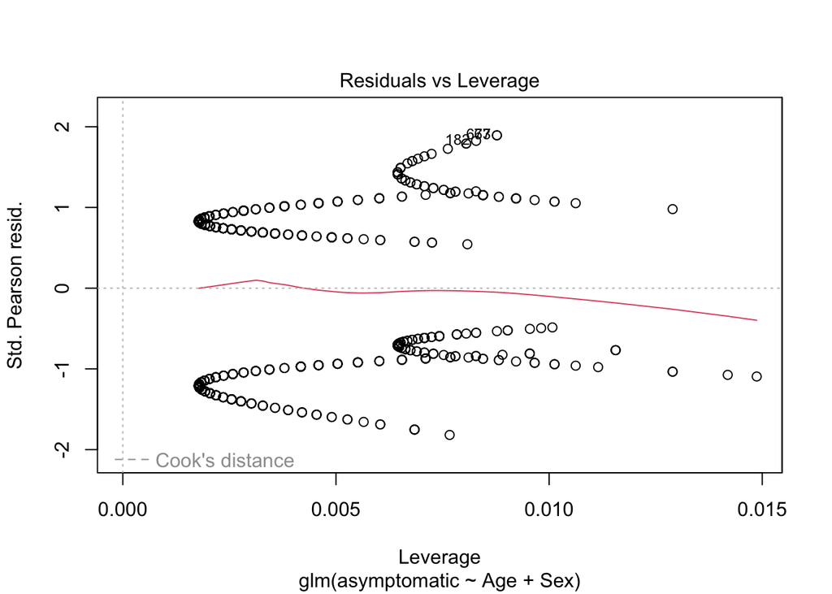

```r
plot(log_reg_model)
```

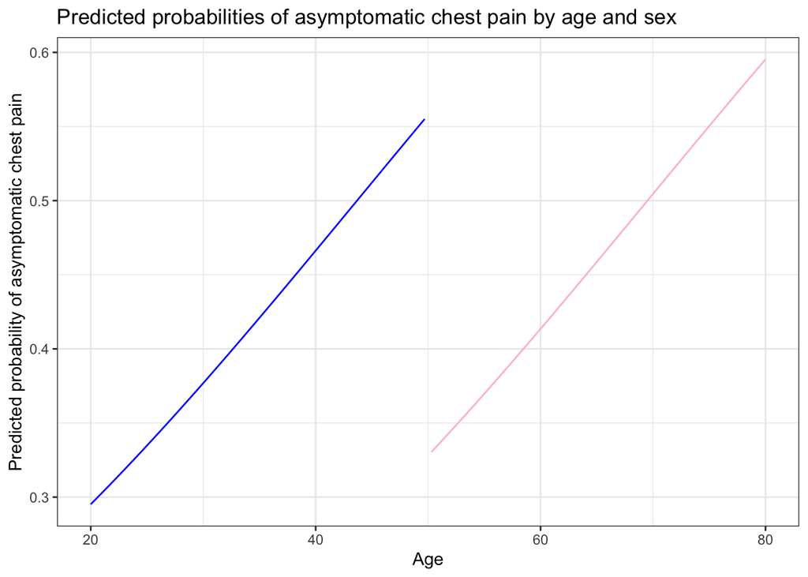

```r
# Load the ggplot2 and dplyr packages
library(ggplot2)
library(dplyr)

# Create a data frame of new values to predict
newdata <- data.frame(Age = seq(20, 80, length.out = 100),
                      Sex = c(rep("M", 50), rep("F", 50)))

# Make predictions for the new values
newdata$yhat <- predict(log_reg_model, newdata, type = "response")

# Reshape the data for plotting
plotdata <- newdata %>%
  mutate(Sex = factor(Sex, levels = c("M", "F"))) %>%
  tidyr::pivot_wider(names_from = Sex, values_from = yhat)

# Plot the predicted probabilities
ggplot(plotdata, aes(x = Age, y = M)) +
  geom_line(color = "blue") +
  geom_line(aes(y = F), color = "pink") +
  xlab("Age") +
  ylab("Predicted probability of asymptomatic chest pain") +
  ggtitle("Predicted probabilities of asymptomatic chest pain by age and sex") +
  scale_color_manual(values = c("blue", "pink"),
                     labels = c("Male", "Female"),
                     name = "Sex") +
  theme_bw()
```

**Final**：

It is important to note that these findings are based on a sample of individuals and may not generalize to the larger population. Further research is necessary to confirm and expand upon these findings. Additionally, the analysis only identifies an association between age, sex, and chest pain type and does not establish causality or directionality of the association. Therefore, healthcare providers should use this information as one piece of a larger diagnostic and treatment plan, while also taking into account other factors and individual patient circumstances.